# A3

Marc Garrido Casas

11/5/2020

```r
setwd("C:/Users/garridom/Documents/UOC/Estadistica/A3")
df <- read.csv("BWprocessed.csv", header = TRUE, sep = ',', row.names=1)
head(df)
```

```
##                       HP      City  Time       Day   BW BPD  AD Sex Ge Sm
## 1 H.G.U.Gregorio Marañón    Madrid 13:20   Viernes 2200  82  90   M 33  N
## 2       H.U.de Bellvitge Barcelona 11:00     Lunes 4100  97 129   M 43  N
## 3       H.U.de Bellvitge Barcelona 00:00    Martes 4200  97 133   F 43  N
## 4               H.Clínic Barcelona 18:38    Jueves 1300  74  71   M 33  S
## 5      H.U.12 de octubre    Madrid 09:53 Miércoles 1150  68  80   F 33  S
## 6 H.G.U.Gregorio Marañón    Madrid 05:40    Sábado 3400  94 110   F 39  N
```

## 1 Model de regressió lineal

### 1.1 Model de regressió lineal univariant

1. Estimar per mínims quadrats ordinaris un model lineal que expliqui la variable pes del bebè en néixer en funció del diàmetre abdominal (AD) abans de néixer. S’avaluarà la bondat de l’ajust, a partir del coeficient de determinació.

```r
library(ggpubr)
```

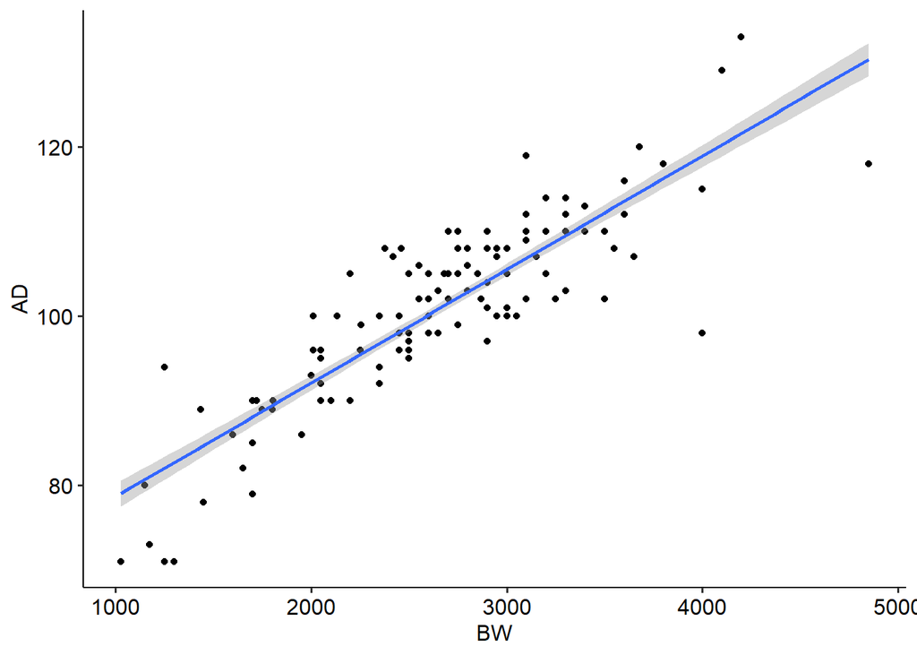

```r
theme_set(theme_pubr())

ggplot(df, aes(x = BW, y = AD)) + geom_point() + stat_smooth(method = lm)
```

```r
cor(df$BW, df$AD)
```

```
## [1] 0.8752187
```

```r
coeficientDeterminacio = cor(df$BW, df$AD)*cor(df$BW, df$AD)
coeficientDeterminacio
```

```
## [1] 0.7660078
```

2. Posteriorment, es dividirà la mostra en dues, segons el sexe del bebè i es repetirà l’estudi per a cada mostra per separat. Raonar els resultats.

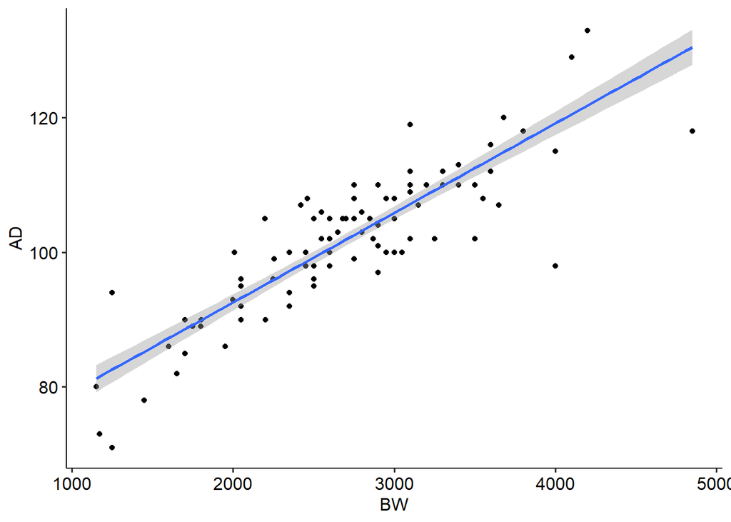

```r
X<-split(df, df$Sex)

ggplot(X[[1]], aes(x = BW, y = AD)) + geom_point() + stat_smooth(method = lm)
```

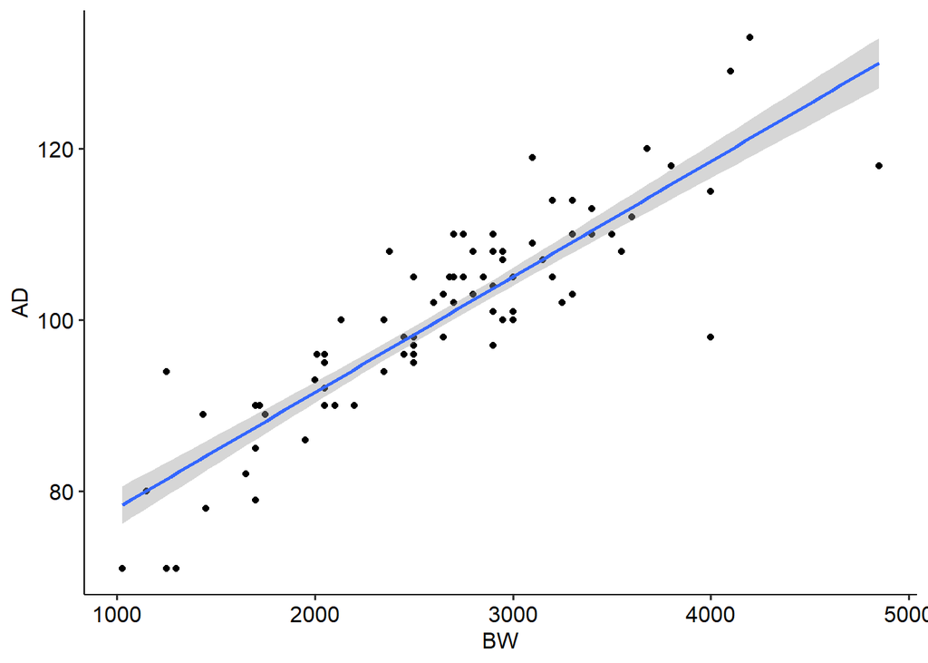

```r
ggplot(X[[2]], aes(x = BW, y = AD)) + geom_point() + stat_smooth(method = lm)
```

```r
cor(X[[1]]$BW, X[[1]]$AD)
```

```
## [1] 0.8704718
```

```r
coeficientDeterminacioF = cor(X[[1]]$BW, X[[1]]$AD)*cor(X[[1]]$BW, X[[1]]$AD)

cor(X[[2]]$BW, X[[2]]$AD)
```

```
## [1] 0.8818439
```

```r
coeficientDeterminacioM = cor(X[[2]]$BW, X[[2]]$AD)*cor(X[[2]]$BW, X[[2]]$AD)
```

```r
coeficientDeterminacioF
```

```
## [1] 0.7577212
```

```r
coeficientDeterminacioM
```

```
## [1] 0.7776487
```

Pel que sembla, el fet de que el nadó sigui mascle, té un xic més en el valor del coeficient de determinació entre el seu pes i el diàmetre abdominal.

Doncs llavors, no crec que influeixi garie ,però la proporció de variació de la variable del diàmetre abdominal explicada pel pes, és lleugerament més gran en mascles que en femelles.

### 1.2 Model de regressió lineal múltiple (regresors quantitatius)

1. Estimar per mínims quadrats ordinaris un model lineal que expliqui la variable pes del bebè en funció del diàmetre abdominal (AD) i el diàmetre biparietal (BPD). Es procedirà a avaluar la bondat d’ajust a través del coeficient de determinació ajustat. Discutir si es produeix una millora del model.

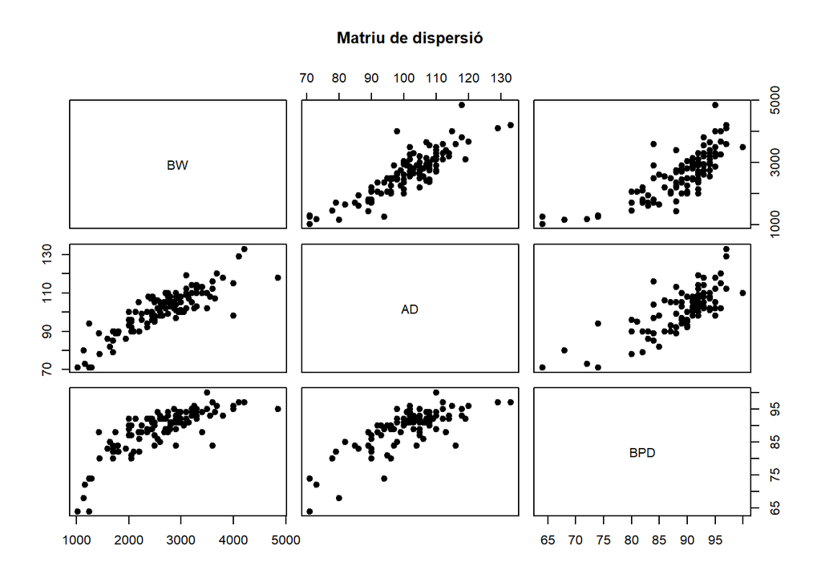

```r
df = df[,c("BW","AD","BPD")]
pairs(df, labels=c("BW","AD","BPD"), main='Matriu de dispersió', cex.main=0.8, cex = 1.5, pch = 20, bg="light blue", cex.labels = 1, font.labels=1)
```

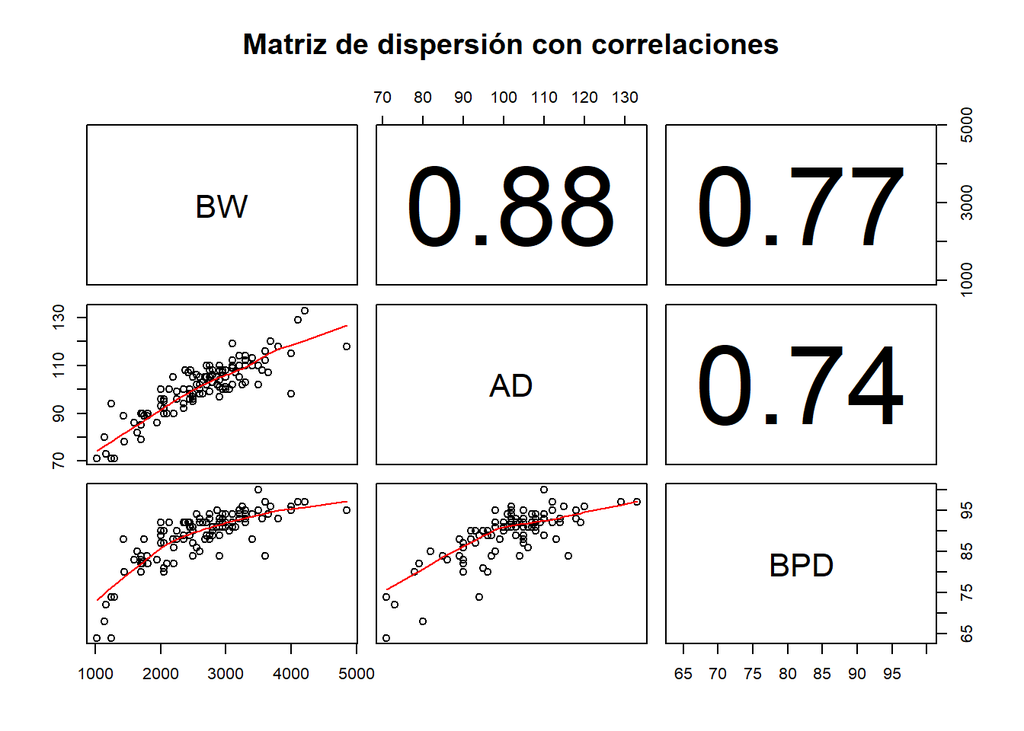

```r
panel.cor <- function(AD, BW, digits=2, prefix="", cex.cor){
  par(usr = c(0, 1, 0, 1))
  r <- abs(cor(AD, BW))
  txt <- format(c(r, 0.123456789), digits=digits)[1]
  txt <- paste(prefix, txt, sep="")
  if(missing(cex.cor))
  cex <- 0.8/strwidth(txt)
  text(0.5, 0.5, txt, cex = cex)
}

pairs(df, lower.panel=panel.smooth, upper.panel=panel.cor,
      main="Matriz de dispersión con correlaciones")
```

```r
mod <- lm(BW ~ AD + BPD, data = df)

summary(mod)
```

```
##
## Call:
## lm(formula = BW ~ AD + BPD, data = df)
##
## Residuals:
##     Min      1Q  Median      3Q     Max
## -714.53 -225.87  -52.55  164.57 1260.53
##
## Coefficients:
##              Estimate Std. Error t value Pr(>|t|)
## (Intercept) -4767.601    279.220 -17.075  < 2e-16 ***
## AD             43.401      2.479  17.510  < 2e-16 ***
## BPD            34.250      4.555   7.519 6.57e-13 ***
## ---
## Signif. codes:  0 '***' 0.001 '**' 0.01 '*' 0.05 '.' 0.1 ' ' 1
##
## Residual standard error: 338.5 on 297 degrees of freedom
## Multiple R-squared:  0.8034, Adjusted R-squared:  0.8021
## F-statistic: 606.9 on 2 and 297 DF,  p-value: < 2.2e-16
```

Vec que R^2 és 0.8 respecte el 0.77 anterior.

2. Estudiar l’existència o no de multicolinealitat entre les covariables del model anterior, AD i BPD. Podeu usar el package faraway.

```r
#install.packages("car")
library(car)
vif(mod)
```

```
##       AD      BPD
## 2.179907 2.179907
```

VIF = 1: Ausencia total de colinialidad 1 < VIF < 5: La regresión puede verse afectada por cierta colinialidad.

Amb una variancia d’inflació tant curta, 2.18, podem asumir que no existeix una multicolinealitat forta.

### 1.3 Model de regressió lineal múltiple (regresors quantitatius i qualitatius)

1. Volem conèixer en quina mesura es relaciona el pes, en funció del diàmetre abdominal, diàmetrebiparietal i les setmanes de gestació. Es recodificará la variable Ge, en menor i major o igual de 35setmanes. Aplicar un model de regressió lineal múltiple i explicar el resultat.

```r
df <- read.csv("BWprocessed.csv", header = TRUE, sep = ',', row.names=1)
df = df[,c("BW","AD","Ge")]
df$Ge[df$Ge<35] <- 0
df$Ge[df$Ge>=35] <- 1
head(df)
```

```
##     BW  AD Ge
## 1 2200  90  0
## 2 4100 129  1
## 3 4200 133  1
## 4 1300  71  0
## 5 1150  80  0
## 6 3400 110  1
```

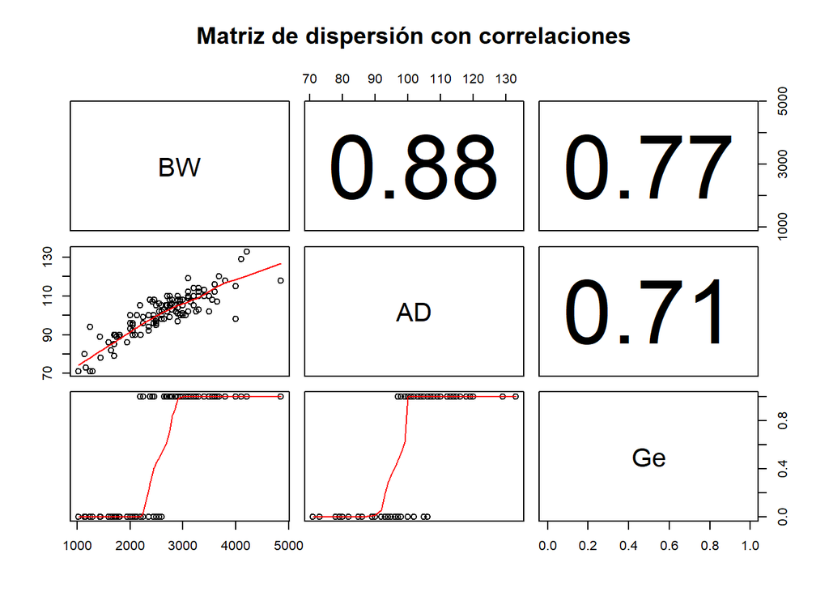

```r
panel.cor <- function(AD, BW, digits=2, prefix="", cex.cor){
  par(usr = c(0, 1, 0, 1))
  r <- abs(cor(AD, BW))
  txt <- format(c(r, 0.123456789), digits=digits)[1]
  txt <- paste(prefix, txt, sep="")
  if(missing(cex.cor))
  cex <- 0.8/strwidth(txt)
  text(0.5, 0.5, txt, cex = cex)
}

pairs(df, lower.panel=panel.smooth, upper.panel=panel.cor,
      main="Matriz de dispersión con correlaciones")
```

```r
mod <- lm(BW ~ AD + Ge, data = df)

summary(mod)
```

```
##
## Call:
## lm(formula = BW ~ AD + Ge, data = df)
##
## Residuals:
##     Min      1Q  Median      3Q     Max
## -869.93 -178.56    0.07  179.16 1264.17
##
## Coefficients:
##             Estimate Std. Error t value Pr(>|t|)
## (Intercept) -1981.88     219.98  -9.009  < 2e-16 ***
## AD             43.64       2.37  18.411  < 2e-16 ***
## Ge            441.35      55.33   7.977 3.28e-14 ***
## ---
## Signif. codes:  0 '***' 0.001 '**' 0.01 '*' 0.05 '.' 0.1 ' ' 1
##
## Residual standard error: 335.2 on 297 degrees of freedom
## Multiple R-squared:  0.8073, Adjusted R-squared:  0.806
## F-statistic: 622.1 on 2 and 297 DF,  p-value: < 2.2e-16
```

2. Ara es calcularà el model de regressió lineal que relacioni el pes amb diàmetre abdominal i diàmetre biparietal, per a la mostra els bebès de la qual han nascut abans de les 35 setmanes. Posteriorment, es calcularà el mateix model, per als bebès nascuts en la setmana 35 i posteriors. En vista dels resultats obtinguts, existeix relació amb l’apartat a)? Raonar la resposta.

```r
df <- read.csv("BWprocessed.csv", header = TRUE, sep = ',', row.names=1)
df = df[,c("BW","AD","BPD","Ge")]
head(df)
```

```
##     BW  AD BPD Ge
## 1 2200  90  82 33
## 2 4100 129  97 43
## 3 4200 133  97 43
## 4 1300  71  74 33
## 5 1150  80  68 33
## 6 3400 110  94 39
```

```r
X<-split(df, df$Ge<35)
df = df[,c("BW","AD","BPD")]

X[[1]] = X[[1]][,c("BW","AD","BPD")]
X[[2]] = X[[2]][,c("BW","AD","BPD")]
```

```r
mod1 <- lm(BW ~ AD + BPD, data = X[[1]])
summary(mod1)
```

```
##
## Call:
## lm(formula = BW ~ AD + BPD, data = X[[1]])
##
## Residuals:
##     Min      1Q  Median      3Q     Max
## -783.04 -234.92  -56.89  199.48 1185.13
##
## Coefficients:
##              Estimate Std. Error t value Pr(>|t|)
## (Intercept) -5392.809    861.680  -6.258 3.50e-09 ***
## AD             34.716      3.971   8.742 3.19e-15 ***
## BPD            52.223      9.855   5.299 3.85e-07 ***
## ---
## Signif. codes:  0 '***' 0.001 '**' 0.01 '*' 0.05 '.' 0.1 ' ' 1
##
## Residual standard error: 368.3 on 158 degrees of freedom
## Multiple R-squared:  0.4958, Adjusted R-squared:  0.4894
## F-statistic: 77.68 on 2 and 158 DF,  p-value: < 2.2e-16
```

```r
mod2 <- lm(BW ~ AD + BPD, data = X[[2]])
summary(mod2)
```

```
##
## Call:
## lm(formula = BW ~ AD + BPD, data = X[[2]])
##
## Residuals:
##    Min     1Q Median     3Q    Max
## -594.6 -117.5   -8.0  146.7  419.6
##
## Coefficients:
##              Estimate Std. Error t value Pr(>|t|)
## (Intercept) -3037.307    219.603 -13.831  < 2e-16 ***
## AD             29.115      2.883  10.100  < 2e-16 ***
## BPD            28.133      3.624   7.764 1.78e-12 ***
## ---
## Signif. codes:  0 '***' 0.001 '**' 0.01 '*' 0.05 '.' 0.1 ' ' 1
##
## Residual standard error: 202.8 on 136 degrees of freedom
## Multiple R-squared:  0.8067, Adjusted R-squared:  0.8038
## F-statistic: 283.7 on 2 and 136 DF,  p-value: < 2.2e-16
```

### 1.4 Diagnosi del model

Es prendrà el model de l’apartat 1.2, que relaciona el pes del bebè en funció del diàmetre abdominal i el diàmetre biparietal. Per a la diagnosi d’aquest model es faran dos gràfics: un amb els valors ajustats enfront dels residus (que ens permetrà veure si la variància és constant) i el gràfic quantil-quantil que compara els residus del model amb els valors d’una variable que es distribueix normalment(QQ plot). Explicar conclusions a partir dels gràfics obtinguts.

```r
df <- read.csv("BWprocessed.csv", header = TRUE, sep = ',', row.names=1)
df = df[,c("BW","AD","BPD")]
mod <- lm(BW ~ AD + BPD, data = df)

summary(mod)
```

```
##
## Call:
## lm(formula = BW ~ AD + BPD, data = df)
##
## Residuals:
##     Min      1Q  Median      3Q     Max
## -714.53 -225.87  -52.55  164.57 1260.53
##
## Coefficients:
##              Estimate Std. Error t value Pr(>|t|)
## (Intercept) -4767.601    279.220 -17.075  < 2e-16 ***
## AD             43.401      2.479  17.510  < 2e-16 ***
## BPD            34.250      4.555   7.519 6.57e-13 ***
## ---
## Signif. codes:  0 '***' 0.001 '**' 0.01 '*' 0.05 '.' 0.1 ' ' 1
##
## Residual standard error: 338.5 on 297 degrees of freedom
## Multiple R-squared:  0.8034, Adjusted R-squared:  0.8021
## F-statistic: 606.9 on 2 and 297 DF,  p-value: < 2.2e-16
```

```r
anova(mod)
```

```
## Analysis of Variance Table
##
## Response: BW
##            Df    Sum Sq   Mean Sq  F value    Pr(>F)
## AD          1 132608492 132608492 1157.355 < 2.2e-16 ***
## BPD         1   6477932   6477932   56.537 6.572e-13 ***
## Residuals 297  34029938    114579
## ---
## Signif. codes:  0 '***' 0.001 '**' 0.01 '*' 0.05 '.' 0.1 ' ' 1
```

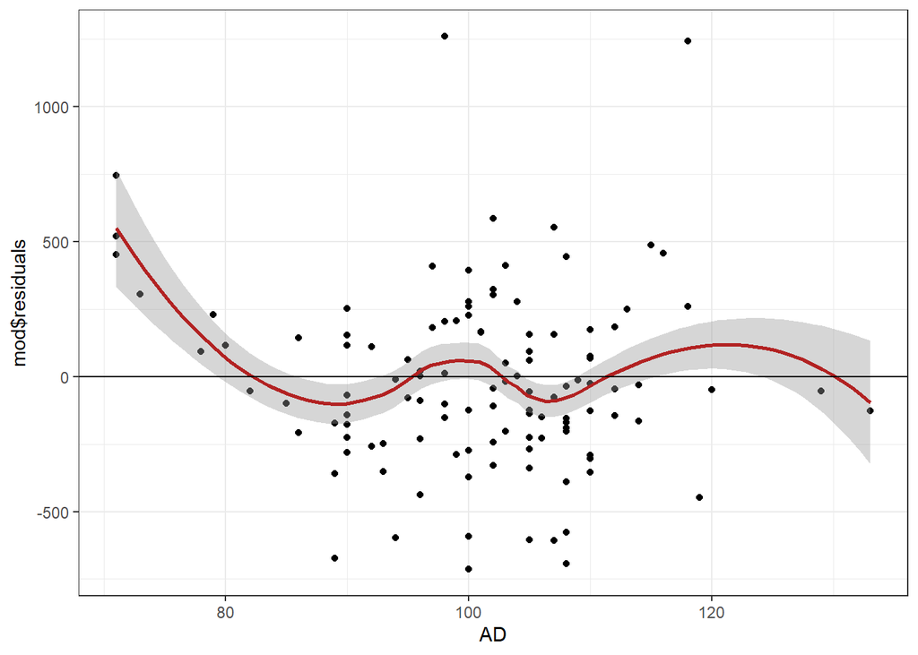

```r
library(ggplot2)
library(gridExtra)
plot1 <- ggplot(data = df, aes(AD, mod$residuals)) +
    geom_point() + geom_smooth(color = "firebrick") + geom_hline(yintercept = 0) +
    theme_bw()
plot1
```

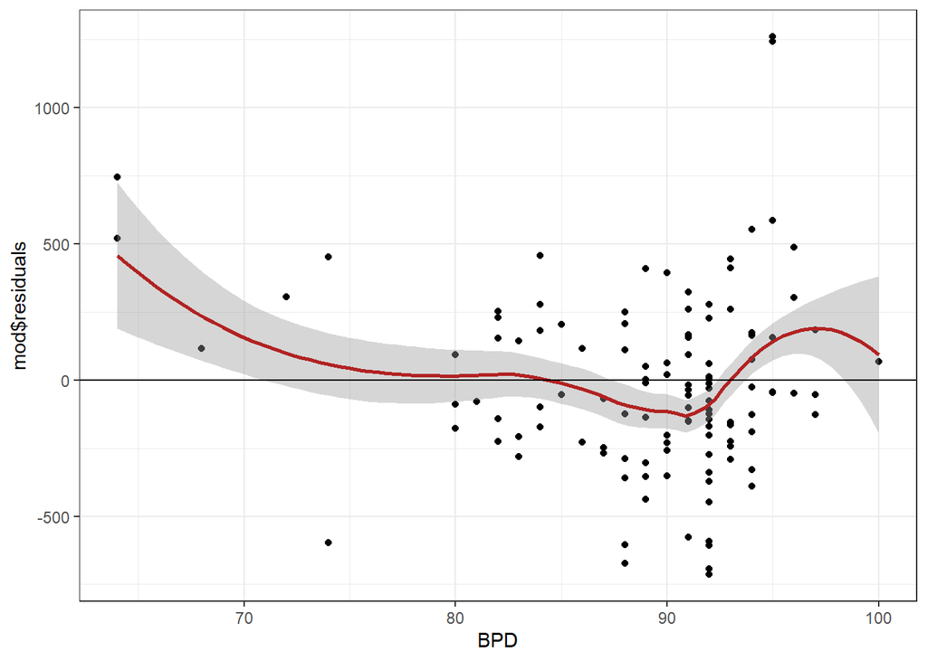

```r
plot2 <- ggplot(data = df, aes(BPD, mod$residuals)) +
    geom_point() + geom_smooth(color = "firebrick") + geom_hline(yintercept = 0) +
    theme_bw()
plot2
```

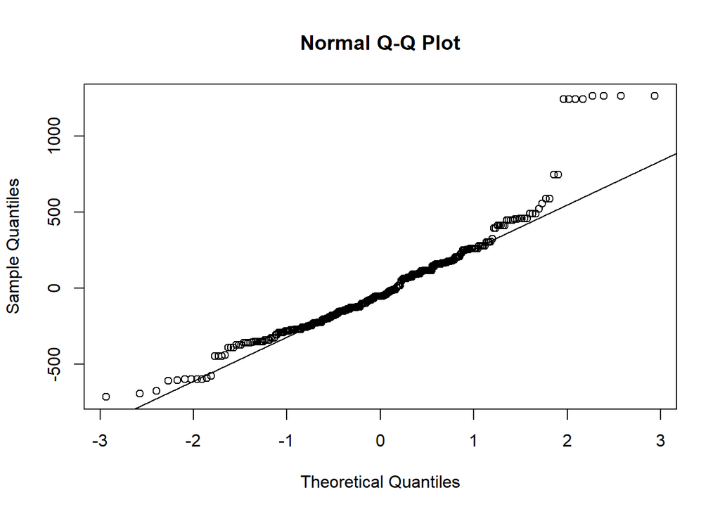

```r
qqnorm(mod$residuals)
qqline(mod$residuals)
```

Observant els primers gràfics del residu, no acaba d’adaptar-se del tot l’eix X. Pel gràfic quantil-quantil, veiem que els punts segueixen més la recta, excepte uns quants punts a l’extrem esquerre i uns bastant més a la dreta que s’allunyen prou de la recta.

No m’atreviria dir que es distribueix de forma normal per la raó que he esmentat anteriorment.

### 1.5 Predicció del model

Segons el model de l’apartat 1.3, calcular el pes d’un bebè amb AD de 94 i BPD de 75, nascut en la setmana 34 de gestació.

```r
df <- read.csv("BWprocessed.csv", header = TRUE, sep = ',', row.names=1)
df = df[,c("BW","AD","BPD","Ge")]

mod <- lm(BW ~ AD + BPD, data = df)

pred.frame <- data.frame(AD=94, BPD=75, Ge=34)
pc <- predict(mod, int="c", newdata=pred.frame)
pc
```

```
##        fit      lwr      upr
## 1 1880.871 1771.295 1990.448
```

fit es refereix al valor mig predit, mentre que lwr i upr es refereis als límits inferior i superior de l’interval predit.

## 2 Model de regressió logística

### 2.1 Estimació de OR (Odds Ràtio)

Es vol estudiar la probabilitat de tenir un bebè amb baix pes (aquells que són inferiors a 2.5 kg). Per a avaluar-la, primer es realitzarà una anàlisi crua dels possibles factors de risc.

1. Estudiar la relació entre el baix pes i cadascuna de les variables següents: • a.1) si la mare és fumadora (Sm)

```r
my.chisq <- function( x, y ){
  n00 <- sum( (x==0) & (y==0) )
  n11 <- sum( (x==1) & (y==1) )
  n01 <- sum( (x==0) & (y==1) )
  n10 <- sum( (x==1) & (y==0) )
  cat("Table values:", n00, " ", n01, " ", n10, " ", n11, "\n")
  nx0 <- sum( x==0)
  nx1 <- sum( x==1)
  ny0 <- sum( y==0)
  ny1 <- sum( y==1)
  cat(nx0, " ", nx1, " ", ny0, " ", ny1, "\n")
  total = sum(nx0, nx1)
  e00 <- (nx0*ny0) / total
  e01 <- (nx0*ny1) / total
  e10 <- (nx1*ny0) / total
  e11 <- (nx1*ny1) / total
  cat("Expected values:", e00, " ", e01, " ", e10, " ", e11, "\n")
  chisq <- (n00-e00)^2 / e00 + (n01-e01)^2/e01 + (n10-e10)^2/e10 + (n11-e11)^2/e11
  df <- 1
  cat("chisq: ", chisq)
  return (chisq)
}
```

```r
df <- read.csv("BWprocessed.csv", header = TRUE, sep = ',', row.names=1)

#Preparació de les dades: selecció dels casos amb baix pes en néixer
alfa <- 0.05
df$lower.BW <- (df$BW < 2500)

#Es crea un data frame amb dues columnes: baix pes i mare fumadora
data <- df[, c("lower.BW" , "Sm")]

#Es codifiquen els valors com 0 i 1.
data$lower.BW <- ifelse( data$lower.BW==TRUE, 1, 0)
data$Sm <- ifelse( data$Sm=='S', 1, 0)

#La funció chisq retorna el valor observat
chisq <- my.chisq( data$lower.BW, data$Sm )
```

```
## Table values: 191   2   47   60
## 193   107   238   62
## Expected values: 153.1133   39.88667   84.88667   22.11333
## chisq:  127.1823
```

```r
table <- table( data$lower.BW, data$Sm)
table
```

```
##
##       0   1
##   0 191   2
##   1  47  60
```

```r
#Si la mare no es fumadora, la probabilitat que sigui de baix pes:
normalOdds = (47/238)/(191/238)
normalOdds
```

```
## [1] 0.2460733
```

```r
log(normalOdds)
```

```
## [1] -1.402126
```

```r
#Si la mare es fumadora:
normalOdds = (60/62)/(2/62)
normalOdds
```

```
## [1] 30
```

```r
log(normalOdds)
```

```
## [1] 3.401197
```

```r
#El ratio és:
30/0.2460733
```

```
## [1] 121.9149
```

```r
log(30/0.2460733)
```

```
## [1] 4.803323
```

• a.2) sexe

```r
df <- read.csv("BWprocessed.csv", header = TRUE, sep = ',', row.names=1)

#Preparació de les dades: selecció dels casos amb baix pes en néixer
alfa <- 0.05
df$lower.BW <- (df$BW < 2500)

#Es crea un data frame amb dues columnes: baix pes i mare fumadora
data <- df[, c("lower.BW" , "Sex")]

#Es codifiquen els valors com 0 i 1.
data$lower.BW <- ifelse( data$lower.BW==TRUE, 1, 0)
data$Sex <- ifelse( data$Sex=='F', 1, 0)

#La funció chisq retorna el valor observat
chisq <- my.chisq( data$lower.BW, data$Sex )
```

```
## Table values: 81   112   51   56
## 193   107   132   168
## Expected values: 84.92   108.08   47.08   59.92
## chisq:  0.9059654
```

```r
table <- table( data$lower.BW, data$Sex)
table
```

```
##
##       0   1
##   0  81 112
##   1  51  56
```

```r
normalOdds = 51/81
normalOdds
```

```
## [1] 0.6296296
```

```r
log(normalOdds)
```

```
## [1] -0.4626235
```

```r
normalOdds = 56/112
normalOdds
```

```
## [1] 0.5
```

```r
log(normalOdds)
```

```
## [1] -0.6931472
```

```r
#El ratio és:
0.5/0.6296296
```

```
## [1] 0.7941177
```

```r
log(0.5/0.6296296)
```

```
## [1] -0.2305236
```

• a.3) setmanes de gestació (Ge), (Es dividirà entre menor i major o igual de 35 setmanes)

```r
df <- read.csv("BWprocessed.csv", header = TRUE, sep = ',', row.names=1)

#Preparació de les dades: selecció dels casos amb baix pes en néixer
alfa <- 0.05
df$lower.BW <- (df$BW < 2500)

#Es crea un data frame amb dues columnes: baix pes i mare fumadora
data <- df[, c("lower.BW" , "Ge")]

#Es codifiquen els valors com 0 i 1.
data$lower.BW <- ifelse( data$lower.BW==TRUE, 1, 0)
data$Ge <- ifelse( data$Ge<35, 1, 0)

#La funció chisq retorna el valor observat
chisq <- my.chisq( data$lower.BW, data$Ge )
```

```
## Table values: 156   37   5   102
## 193   107   161   139
## Expected values: 103.5767   89.42333   57.42333   49.57667
## chisq:  160.5577
```

```r
table <- table( data$lower.BW, data$Ge)
table
```

```
##
##       0   1
##   0 156  37
##   1   5 102
```

```r
normalOdds = 5/156
normalOdds
```

```
## [1] 0.03205128
```

```r
log(normalOdds)
```

```
## [1] -3.440418
```

```r
normalOdds = 102/37
normalOdds
```

```
## [1] 2.756757
```

```r
log(normalOdds)
```

```
## [1] 1.014055
```

```r
#El ratio és:
0.03205128/2.756757
```

```
## [1] 0.01162644
```

```r
log(0.03205128/2.756757)
```

```
## [1] -4.454473
```

Es demana: Estimar i interpretar les OR en cada cas. Per a comprovar si existeix associació entre la variable dependent i cadascuna de les variables explicatives, s’aplicarà el test Chi-quadrat de Pearson. Un resultat significatiu ens dirà que existeix associació. Posteriorment, per a conèixer el grau d’aquesta associació, es calcularà les OR.

NOTA: Per al càlcul de les OR, es partirà de la taula de contingència i es calcularà a partir de la seva fórmula.

2. Si no s’hi hagués recodificado la variable setmanes de gestació, podríem seguir el procediment anterior per al càlcul de la OR? Explicar la resposta.

No, per fer un càlcul de Odds Ratio, necessitem una regressió logística, i per tenir una regressió logística, necessitem que la variable sigui binària, zeros o uns. La variable de setmanes de gestació és una variable numèrica que ocupa un rang de valors més grans que dos nombres, per tant no hi podriem fer uan regressió logñistica.

3. Si volem veure la relació entre baix pes i lloc de procedència, podríem seguir el procediment anterior per al càlcul de la OR? En el cas que la resposta fos negativa, quina seria una solució?

No, per a fer un càlcul d’OR, necessitem una relació logistica i per això necesitem una variable de dos nombres, zeros i uns. Si tenim una variable categòrica on tenim molts possibles valors per un atribut no númèric, ens serà impossible separar-los en zeros i uns.

Una possible solució podria ser fer un atribut per a cada lloc de procedència i posar un 1 si és d’allà, un 0 si no ho és. Llavors podrem veure la relació amb un lloc de procedència en concret. Podriem adaptar això per fer-ho amb tots els llocs de procedència per separats. Un altre forma seria separar el lloc de procedència entre per exemple, est d’Espnaña o oest d’España, però possiblement perdriem informació o else resultats no serien valorables.